# Introduction

Soit $f:[0,1]\longrightarrow \mathbb{R}$ d??finie pour tout $x\in[0,1]$ par $f(x) = \dfrac{1}{2}x(1-x)$.

On se propose d'??tudier le comportement des suites r??currentes de relation de r??currence $u_{n+1}=f(u_n)$.

# Étude générale

Soit $u_0\in[0,1]$, et $(u_n)$ la suite d??finie par $u_{n+1} = f(u_n)$ pour tout $n\in\mathbb{N}$.

# Comportement asymptotique

On s'appuiera ici sur l'utilisation du langage informatique Python pour analyser le comportement de $u_n$ pour $n$ grand.

Tout d'abord, on importe dans l'instance Python d??marr??e les librairies de fonctions qui vont nous permettre, respectivement, de tracer des graphes (`matplotlib` et son module `matplotlib.pyplot`) et mener des calculs math??matiques (`numpy`):

```python
import matplotlib as mpl
%matplotlib inline
from IPython.display import set_matplotlib_formats
set_matplotlib_formats('png', 'pdf')
import matplotlib.pyplot as plt
import numpy as np
from ipywidgets import interact,widgets
```

On peut maintenant d??finir la fonction $f$ de la relation de r??currence:

```python
def f(x):
    return 0.5*x*(1-x)
```

Et calculer quelques termes de la suite $(u_n)$ :

```python
U = [0.5]
n = 30

for i in range(n):
    U.append(f(U[-1]))
```

Et enfin construire une figure `fig` constitu??e de deux graphes `ax0` et `ax1`, respectivement les termes de la suite $u_n$ et ceux de la suite $2^nu_n$:

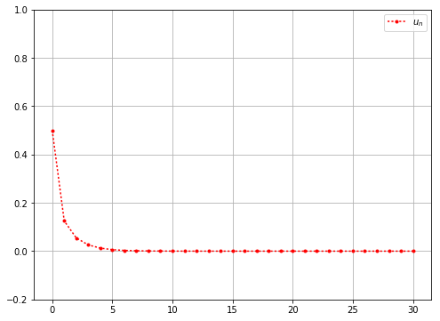

```python
fig0, ax0 = plt.subplots(1,1, figsize=(8,6))

ax0.grid()
ax0.set_ylim(bottom=-0.2)
ax0.plot(U, 'r.:', label = r'$u_n$')
ax0.legend()
```

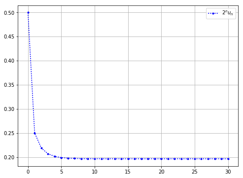

```python
fig1, ax1 = plt.subplots(1,1, figsize=(8,6))

ax1.grid()
def build_aux():
    su = [u*2**i for i,u in enumerate(U)]
    return su
s = build_aux()
ax1.plot(s, 'b.:', label= r'$2^nu_n$')
ax1.legend()
```

Pour avoir une id??e de vers quoi tend $2^nu_n$, on peut prendre les derniers termes calcul??s:

```python
s[-11:-1]
```

```
[0.19645349999004186,
 0.1964534631839566,
 0.19645344478092086,
 0.19645343557940473,
 0.1964534309786471,
 0.19645342867826837,
 0.19645342752807904,
 0.19645342695298437,
 0.19645342666543705,
 0.1964534265216634]
```

Ainsi, on a que $2^nu_n \longrightarrow C$, o?? $C \approx 0.196$ ?? $10^{-3}$ pr??s, d'o??

$$ u_n \simeq \frac{0.196}{2^n}. $$

# Une autre suite

On s'int??resse ici aux suites v??rifiant une relation de r??currence de la forme $$ u_{n+1} = a\sin(u_n) $$ o?? $a\in\mathbb R$ est fix??.

On propose le programme suivant : les deux variables `a` et `u0` peuvent ??tre ajust??es pour ??tudier le comportement de la suite.

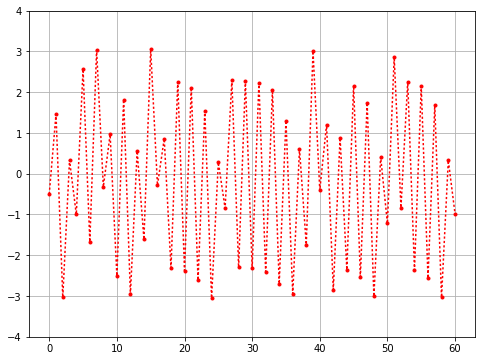

```python
###### D??finition de f

def plot_u(a,u0):
    def F(x):
        return a*np.sin(x)

    U = [u0]
    n = 60

    for i in range(n):
        U.append(F(U[-1]))

    fig = plt.figure(figsize=(8,6))
    ax = fig.add_subplot(1,1,1)
    ax.grid()
    ax.set_ylim(bottom=-4,top=4)
    ax.plot(U, 'r.:')
    ax.set_xlim()

# ??l??ments interactifs / sliders

interact(plot_u,
        a = widgets.FloatSlider(value=1,min=-4.,max=4.,step=0.05),
        u0 = widgets.FloatSlider(value=1,min=-1.,max=1.,step=0.05))
```